# hw08

張瑜君

2019年4月8日

```r
con = gzcon(url('http://www.systematicportfolio.com/sit.gz', 'rb'))
source(con)
close(con)

load.packages('quantmod')
```

```
## Version 0.4-0 included new data defaults. See ?getSymbols.
```

讀取etf4_xts_all的資料，有0050、0056、006205、00646四筆資料，並且去掉NA值。

```r
etf4.all<-readRDS("D:/gitest/gitest01/0408/etf4_xts_all")
head(etf4.all)
```

```
##             0050  0056 006205 00646
## 2009-01-05 34.30 14.00     NA    NA
## 2009-01-06 34.21 14.02     NA    NA
## 2009-01-07 34.59 14.28     NA    NA
## 2009-01-08 33.21 13.86     NA    NA
## 2009-01-09 32.32 13.61     NA    NA
## 2009-01-10 31.91 13.55     NA    NA
```

```r
str(etf4.all)
```

```
## An 'xts' object on 2009-01-05/2018-12-28 containing:
##   Data: num [1:2474, 1:4] 34.3 34.2 34.6 33.2 32.3 ...
##  - attr(*, "dimnames")=List of 2
##   ..$ : NULL
##   ..$ : chr [1:4] "0050" "0056" "006205" "00646"
##   Indexed by objects of class: [Date] TZ: UTC
##   xts Attributes:
##  NULL
```

```r
etf4.all.1<-etf4.all[complete.cases(etf4.all),]
head(etf4.all.1)
```

```
##             0050  0056 006205 00646
## 2015-12-14 59.35 21.06  30.98 19.54
## 2015-12-15 59.59 21.25  31.66 19.70
## 2015-12-16 60.11 21.50  31.67 19.80
## 2015-12-17 60.78 21.76  32.06 20.05
## 2015-12-18 60.78 21.97  32.23 19.87
## 2015-12-21 60.31 21.99  32.62 19.64
```

```r
tail(etf4.all.1)
```

```
##             0050  0056 006205 00646
## 2018-12-22 74.75 24.15  25.08 22.93
## 2018-12-24 74.67 24.16  25.25 22.72
## 2018-12-25 73.57 23.90  24.90 22.51
## 2018-12-26 73.87 23.83  25.16 22.13
## 2018-12-27 74.81 23.96  25.30 22.95
## 2018-12-28 75.21 23.92  25.24 23.16
```

# 0050

讀取0050的資料。

```r
library(xts)
data1<-new.env()
data1$prices<-etf4.all.1$'0050'
prices<-data1$prices

sma50<-SMA(prices, 50)
head(sma50, 51)
```

```
##                SMA
## 2015-12-14      NA
## 2015-12-15      NA
## 2015-12-16      NA
## 2015-12-17      NA
## 2015-12-18      NA
## 2015-12-21      NA
## 2015-12-22      NA
## 2015-12-23      NA
## 2015-12-24      NA
## 2015-12-25      NA
## 2015-12-28      NA
## 2015-12-29      NA
## 2015-12-30      NA
## 2015-12-31      NA
## 2016-01-04      NA
## 2016-01-05      NA
## 2016-01-06      NA
## 2016-01-07      NA
## 2016-01-08      NA
## 2016-01-11      NA
## 2016-01-12      NA
## 2016-01-13      NA
## 2016-01-14      NA
## 2016-01-15      NA
## 2016-01-18      NA
## 2016-01-19      NA
## 2016-01-20      NA
## 2016-01-21      NA
## 2016-01-22      NA
## 2016-01-25      NA
## 2016-01-26      NA
## 2016-01-27      NA
## 2016-01-28      NA
## 2016-01-29      NA
## 2016-01-30      NA
## 2016-02-01      NA
## 2016-02-02      NA
## 2016-02-03      NA
## 2016-02-15      NA
## 2016-02-16      NA
## 2016-02-17      NA
## 2016-02-18      NA
## 2016-02-19      NA
## 2016-02-22      NA
## 2016-02-23      NA
## 2016-02-24      NA
## 2016-02-25      NA
## 2016-02-26      NA
## 2016-03-01      NA
## 2016-03-02 59.2194
## 2016-03-03 59.2900
```

分別看日期、價錢。

```r
bt.prep(data1, align='keep.all')
names(data1)
```

```
## [1] "prices"          "dates"           "weight"          "symbolnames"
## [5] "execution.price"
```

```r
data1$dates
```

```
##   [1] "2015-12-14" "2015-12-15" "2015-12-16" "2015-12-17" "2015-12-18"
##   [6] "2015-12-21" "2015-12-22" "2015-12-23" "2015-12-24" "2015-12-25"
##  [11] "2015-12-28" "2015-12-29" "2015-12-30" "2015-12-31" "2016-01-04"
##  [16] "2016-01-05" "2016-01-06" "2016-01-07" "2016-01-08" "2016-01-11"
##  [21] "2016-01-12" "2016-01-13" "2016-01-14" "2016-01-15" "2016-01-18"
##  [26] "2016-01-19" "2016-01-20" "2016-01-21" "2016-01-22" "2016-01-25"
##  [31] "2016-01-26" "2016-01-27" "2016-01-28" "2016-01-29" "2016-01-30"
##  [36] "2016-02-01" "2016-02-02" "2016-02-03" "2016-02-15" "2016-02-16"
##  [41] "2016-02-17" "2016-02-18" "2016-02-19" "2016-02-22" "2016-02-23"
##  [46] "2016-02-24" "2016-02-25" "2016-02-26" "2016-03-01" "2016-03-02"
##  [51] "2016-03-03" "2016-03-04" "2016-03-07" "2016-03-08" "2016-03-09"
##  [56] "2016-03-10" "2016-03-11" "2016-03-14" "2016-03-15" "2016-03-16"
##  [61] "2016-03-17" "2016-03-18" "2016-03-21" "2016-03-22" "2016-03-23"
##  [66] "2016-03-24" "2016-03-25" "2016-03-28" "2016-03-29" "2016-03-30"
##  [71] "2016-03-31" "2016-04-01" "2016-04-06" "2016-04-07" "2016-04-08"
```

[output cut: 136 more lines]

```r
data1$prices
```

```
##            prices
## 2015-12-14     NA
## 2015-12-15     NA
## 2015-12-16     NA
## 2015-12-17     NA
## 2015-12-18     NA
## 2015-12-21     NA
## 2015-12-22     NA
## 2015-12-23     NA
## 2015-12-24     NA
## 2015-12-25     NA
## 2015-12-28     NA
## 2015-12-29     NA
## 2015-12-30     NA
## 2015-12-31     NA
## 2016-01-04     NA
## 2016-01-05     NA
## 2016-01-06     NA
## 2016-01-07     NA
## 2016-01-08     NA
## 2016-01-11     NA
## 2016-01-12     NA
## 2016-01-13     NA
## 2016-01-14     NA
## 2016-01-15     NA
## 2016-01-18     NA
## 2016-01-19     NA
## 2016-01-20     NA
## 2016-01-21     NA
## 2016-01-22     NA
## 2016-01-25     NA
## 2016-01-26     NA
## 2016-01-27     NA
## 2016-01-28     NA
## 2016-01-29     NA
## 2016-01-30     NA
## 2016-02-01     NA
## 2016-02-02     NA
## 2016-02-03     NA
## 2016-02-15     NA
```

[output cut: 697 more lines]

```
## 2018-12-11     NA
## 2018-12-12     NA
## 2018-12-13     NA
## 2018-12-14     NA
## 2018-12-17     NA
## 2018-12-18     NA
## 2018-12-19     NA
## 2018-12-20     NA
## 2018-12-21     NA
## 2018-12-22     NA
## 2018-12-24     NA
## 2018-12-25     NA
## 2018-12-26     NA
## 2018-12-27     NA
## 2018-12-28     NA
```

```r
data1$prices<-prices

class(data1$dates)
```

```
## [1] "Date"
```

```r
data1$execution.price = prices
data1$weight[] = 1
buy.hold.0050 <- bt.run.share(data1, clean.signal=F, trade.summary = TRUE)
```

```
## Latest weights :
##            prices
## 2018-12-28    100
##
## Performance summary :
##  CAGR    Best    Worst
##  8.1 2.3 -5.4
```

```r
buy.hold.0050 <-bt.run(data1)
```

```
## Latest weights :
##            prices
## 2018-12-28    100
##
## Performance summary :
##  CAGR    Best    Worst
##  8.1 2.3 -5.4
```

讀取sma 200天的資料。

```r
prices<-data1$prices
sma200<-SMA(prices, 200)
head(sma200, 201)
```

```
##                 SMA
## 2015-12-14       NA
## 2015-12-15       NA
## 2015-12-16       NA
## 2015-12-17       NA
## 2015-12-18       NA
## 2015-12-21       NA
## 2015-12-22       NA
## 2015-12-23       NA
## 2015-12-24       NA
## 2015-12-25       NA
## 2015-12-28       NA
## 2015-12-29       NA
## 2015-12-30       NA
## 2015-12-31       NA
## 2016-01-04       NA
## 2016-01-05       NA
## 2016-01-06       NA
## 2016-01-07       NA
## 2016-01-08       NA
## 2016-01-11       NA
## 2016-01-12       NA
## 2016-01-13       NA
## 2016-01-14       NA
## 2016-01-15       NA
## 2016-01-18       NA
## 2016-01-19       NA
## 2016-01-20       NA
## 2016-01-21       NA
## 2016-01-22       NA
## 2016-01-25       NA
## 2016-01-26       NA
## 2016-01-27       NA
## 2016-01-28       NA
## 2016-01-29       NA
## 2016-01-30       NA
## 2016-02-01       NA
## 2016-02-02       NA
## 2016-02-03       NA
## 2016-02-15       NA
```

[output cut: 147 more lines]

```
## 2016-09-19       NA
## 2016-09-20       NA
## 2016-09-21       NA
## 2016-09-22       NA
## 2016-09-23       NA
## 2016-09-26       NA
## 2016-09-29       NA
## 2016-09-30       NA
## 2016-10-03       NA
## 2016-10-04       NA
## 2016-10-05       NA
## 2016-10-06       NA
## 2016-10-07       NA
## 2016-10-11 64.26940
## 2016-10-12 64.33245
```

```r
data1$weight[] <- iif(prices >= sma200, 1, 0)
sma200.0050 <- bt.run(data1, trade.summary=T)
```

```
## Latest weights :
##            prices
## 2018-12-28      0
##
## Performance summary :
##  CAGR    Best    Worst
##  2.2 1.6 -4
```

讀取sma 50天的資料。

```r
sma50<-SMA(prices, 50)
head(sma50, 51)
```

```
##                SMA
## 2015-12-14      NA
## 2015-12-15      NA
## 2015-12-16      NA
## 2015-12-17      NA
## 2015-12-18      NA
## 2015-12-21      NA
## 2015-12-22      NA
## 2015-12-23      NA
## 2015-12-24      NA
## 2015-12-25      NA
## 2015-12-28      NA
## 2015-12-29      NA
## 2015-12-30      NA
## 2015-12-31      NA
## 2016-01-04      NA
## 2016-01-05      NA
## 2016-01-06      NA
## 2016-01-07      NA
## 2016-01-08      NA
## 2016-01-11      NA
## 2016-01-12      NA
## 2016-01-13      NA
## 2016-01-14      NA
## 2016-01-15      NA
## 2016-01-18      NA
## 2016-01-19      NA
## 2016-01-20      NA
## 2016-01-21      NA
## 2016-01-22      NA
## 2016-01-25      NA
## 2016-01-26      NA
## 2016-01-27      NA
## 2016-01-28      NA
## 2016-01-29      NA
## 2016-01-30      NA
## 2016-02-01      NA
## 2016-02-02      NA
## 2016-02-03      NA
## 2016-02-15      NA
## 2016-02-16      NA
## 2016-02-17      NA
## 2016-02-18      NA
## 2016-02-19      NA
## 2016-02-22      NA
## 2016-02-23      NA
## 2016-02-24      NA
## 2016-02-25      NA
## 2016-02-26      NA
## 2016-03-01      NA
## 2016-03-02 59.2194
## 2016-03-03 59.2900
```

```r
data1$weight[] <- iif(prices >= sma50, 1, 0)
sma50.0050 <- bt.run(data1, trade.summary=T)
```

```
## Latest weights :
##            prices
## 2018-12-28      0
##
## Performance summary :
##  CAGR    Best    Worst
##  3.3 2.2 -2.4
```

```r
data1$weight[] <- iif(prices >= sma50, 1, -1)
sma50.0050.short <- bt.run(data1, trade.summary=T)
```

```
## Latest weights :
##            prices
## 2018-12-28   -100
##
## Performance summary :
##  CAGR    Best    Worst
##  -2.2    5.4 -2.4
```

# 第一、二張圖：

黑色線為SMA50 1.10，紅色線為SMA200 1.07，綠色線為SMA50_short 0.94，藍色線為BH 0050 1.27。並顯示出表格。

# 第三張圖：

顯示出Sharpe、DVR、Cagr、MaxDD四個的長條圖。

# 第四張圖：

顯示為表格。

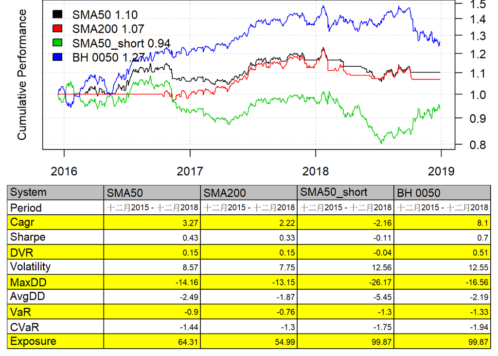

```r
models<-list("SMA50"= sma50.0050,
             "SMA200"= sma200.0050,
             "SMA50_short" = sma50.0050.short,
             "BH 0050" = buy.hold.0050)
strategy.performance.snapshoot(models, T)
```

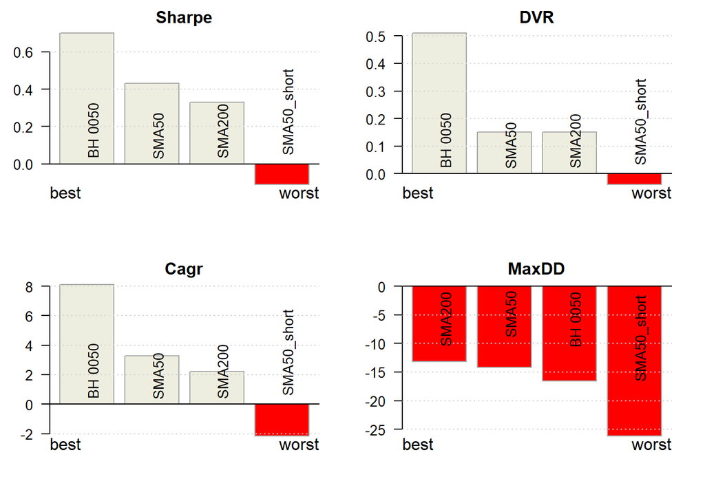

```r
strategy.performance.snapshoot(models, control=list(comparison=T), sort.performance=T)
```

```
##            SMA50                     SMA200
## Period     "十二月2015 - 十二月2018" "十二月2015 - 十二月2018"
## Cagr       "3.27"                    "2.22"
## Sharpe     "0.43"                    "0.33"
## DVR        "0.15"                    "0.15"
## Volatility "8.57"                    "7.75"
## MaxDD      "-14.16"                  "-13.15"
## AvgDD      "-2.49"                   "-1.87"
## VaR        "-0.9"                    "-0.76"
## CVaR       "-1.44"                   "-1.3"
## Exposure   "64.31"                   "54.99"
##            SMA50_short               BH 0050
## Period     "十二月2015 - 十二月2018" "十二月2015 - 十二月2018"
## Cagr       "-2.16"                   "8.1"
## Sharpe     "-0.11"                   "0.7"
## DVR        "-0.04"                   "0.51"
## Volatility "12.56"                   "12.55"
## MaxDD      "-26.17"                  "-16.56"
## AvgDD      "-5.45"                   "-2.19"
## VaR        "-1.3"                    "-1.33"
## CVaR       "-1.75"                   "-1.94"
## Exposure   "99.87"                   "99.87"
```

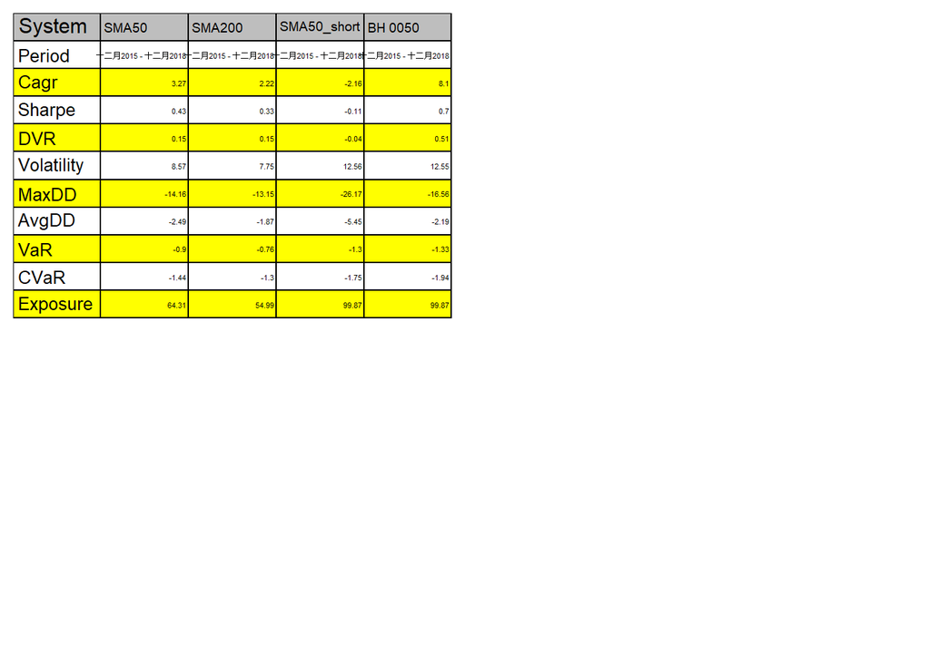

```r
plotbt.strategy.sidebyside(models, return.table=T)
```

```r
library(ggplot2)
all.0050<-merge.xts(sma50.0050$equity,
            sma50.0050.short$equity,
            sma200.0050$equity,
            buy.hold.0050$equity)
colnames(all.0050)<-c("sma50", "sma50 short", "sma200", "BH")
head(all.0050)
```

```
##            sma50 sma50 short sma200       BH
## 2015-12-14     1   1.0000000      1 1.000000
## 2015-12-15     1   0.9959562      1 1.004044
## 2015-12-16     1   0.9872652      1 1.012805
## 2015-12-17     1   0.9762609      1 1.024094
## 2015-12-18     1   0.9762609      1 1.024094
## 2015-12-21     1   0.9838101      1 1.016175
```

```r
all.0050.long<-fortify(all.0050, melt=T)
head(all.0050.long)
```

```
##        Index Series Value
## 1 2015-12-14  sma50     1
## 2 2015-12-15  sma50     1
## 3 2015-12-16  sma50     1
## 4 2015-12-17  sma50     1
## 5 2015-12-18  sma50     1
## 6 2015-12-21  sma50     1
```

圖的標題為Cumulative returns of 0050s。

X軸為year，Y軸為cumulative returns。

橘色線為sma50，綠色線為sma50 short，藍色線為sma200，紫色線為BH。

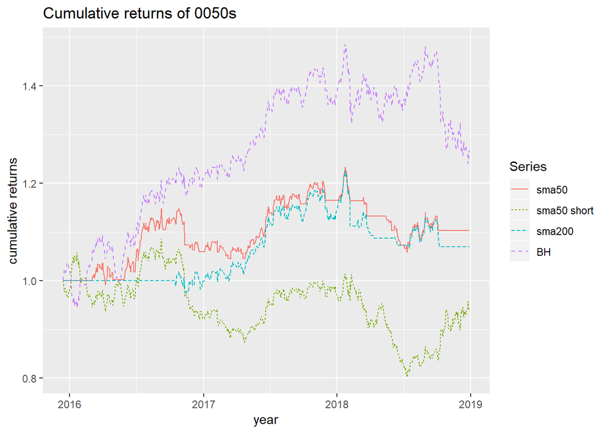

```r
title = "Cumulative returns of 0050s"
p = ggplot(all.0050.long, aes(x = Index, y = Value)) +
  geom_line(aes(linetype = Series, color = Series)) +
  #geom_point(aes(shape = Series))+
  xlab("year") + ylab("cumulative returns")+
  ggtitle(title)
p
```

# 0056

讀取0056的資料。

```r
library(xts)
data1<-new.env()
data1$prices<-etf4.all.1$'0056'
prices<-data1$prices

sma56<-SMA(prices, 50)
head(sma56, 51)
```

```
##                SMA
## 2015-12-14      NA
## 2015-12-15      NA
## 2015-12-16      NA
## 2015-12-17      NA
## 2015-12-18      NA
## 2015-12-21      NA
## 2015-12-22      NA
## 2015-12-23      NA
## 2015-12-24      NA
## 2015-12-25      NA
## 2015-12-28      NA
## 2015-12-29      NA
## 2015-12-30      NA
## 2015-12-31      NA
## 2016-01-04      NA
## 2016-01-05      NA
## 2016-01-06      NA
## 2016-01-07      NA
## 2016-01-08      NA
## 2016-01-11      NA
## 2016-01-12      NA
## 2016-01-13      NA
## 2016-01-14      NA
## 2016-01-15      NA
## 2016-01-18      NA
## 2016-01-19      NA
## 2016-01-20      NA
## 2016-01-21      NA
## 2016-01-22      NA
## 2016-01-25      NA
## 2016-01-26      NA
## 2016-01-27      NA
## 2016-01-28      NA
## 2016-01-29      NA
## 2016-01-30      NA
## 2016-02-01      NA
## 2016-02-02      NA
## 2016-02-03      NA
## 2016-02-15      NA
## 2016-02-16      NA
## 2016-02-17      NA
## 2016-02-18      NA
## 2016-02-19      NA
## 2016-02-22      NA
## 2016-02-23      NA
## 2016-02-24      NA
## 2016-02-25      NA
## 2016-02-26      NA
## 2016-03-01      NA
## 2016-03-02 21.4786
## 2016-03-03 21.5132
```

分別看日期、價錢。

```r
bt.prep(data1, align='keep.all')
names(data1)
```

```
## [1] "prices"          "dates"           "weight"          "symbolnames"
## [5] "execution.price"
```

```r
data1$dates
```

```
##   [1] "2015-12-14" "2015-12-15" "2015-12-16" "2015-12-17" "2015-12-18"
##   [6] "2015-12-21" "2015-12-22" "2015-12-23" "2015-12-24" "2015-12-25"
##  [11] "2015-12-28" "2015-12-29" "2015-12-30" "2015-12-31" "2016-01-04"
##  [16] "2016-01-05" "2016-01-06" "2016-01-07" "2016-01-08" "2016-01-11"
##  [21] "2016-01-12" "2016-01-13" "2016-01-14" "2016-01-15" "2016-01-18"
##  [26] "2016-01-19" "2016-01-20" "2016-01-21" "2016-01-22" "2016-01-25"
##  [31] "2016-01-26" "2016-01-27" "2016-01-28" "2016-01-29" "2016-01-30"
##  [36] "2016-02-01" "2016-02-02" "2016-02-03" "2016-02-15" "2016-02-16"
##  [41] "2016-02-17" "2016-02-18" "2016-02-19" "2016-02-22" "2016-02-23"
##  [46] "2016-02-24" "2016-02-25" "2016-02-26" "2016-03-01" "2016-03-02"
##  [51] "2016-03-03" "2016-03-04" "2016-03-07" "2016-03-08" "2016-03-09"
##  [56] "2016-03-10" "2016-03-11" "2016-03-14" "2016-03-15" "2016-03-16"
##  [61] "2016-03-17" "2016-03-18" "2016-03-21" "2016-03-22" "2016-03-23"
##  [66] "2016-03-24" "2016-03-25" "2016-03-28" "2016-03-29" "2016-03-30"
##  [71] "2016-03-31" "2016-04-01" "2016-04-06" "2016-04-07" "2016-04-08"
```

[output cut: 136 more lines]

```r
data1$prices
```

```
##            prices
## 2015-12-14     NA
## 2015-12-15     NA
## 2015-12-16     NA
## 2015-12-17     NA
## 2015-12-18     NA
## 2015-12-21     NA
## 2015-12-22     NA
## 2015-12-23     NA
## 2015-12-24     NA
## 2015-12-25     NA
## 2015-12-28     NA
## 2015-12-29     NA
## 2015-12-30     NA
## 2015-12-31     NA
## 2016-01-04     NA
## 2016-01-05     NA
## 2016-01-06     NA
## 2016-01-07     NA
## 2016-01-08     NA
## 2016-01-11     NA
## 2016-01-12     NA
## 2016-01-13     NA
## 2016-01-14     NA
## 2016-01-15     NA
## 2016-01-18     NA
## 2016-01-19     NA
## 2016-01-20     NA
## 2016-01-21     NA
## 2016-01-22     NA
## 2016-01-25     NA
## 2016-01-26     NA
## 2016-01-27     NA
## 2016-01-28     NA
## 2016-01-29     NA
## 2016-01-30     NA
## 2016-02-01     NA
## 2016-02-02     NA
## 2016-02-03     NA
## 2016-02-15     NA
```

[output cut: 697 more lines]

```
## 2018-12-11     NA
## 2018-12-12     NA
## 2018-12-13     NA
## 2018-12-14     NA
## 2018-12-17     NA
## 2018-12-18     NA
## 2018-12-19     NA
## 2018-12-20     NA
## 2018-12-21     NA
## 2018-12-22     NA
## 2018-12-24     NA
## 2018-12-25     NA
## 2018-12-26     NA
## 2018-12-27     NA
## 2018-12-28     NA
```

```r
data1$prices<-prices

class(data1$dates)
```

```
## [1] "Date"
```

```r
data1$execution.price = prices
data1$weight[] = 1
buy.hold.0056 <- bt.run.share(data1, clean.signal=F, trade.summary = TRUE)
```

```
## Latest weights :
##            prices
## 2018-12-28    100
##
## Performance summary :
##  CAGR    Best    Worst
##  4.3 2.2 -6
```

```r
buy.hold.0056 <-bt.run(data1)
```

```
## Latest weights :
##            prices
## 2018-12-28    100
##
## Performance summary :
##  CAGR    Best    Worst
##  4.3 2.2 -6
```

讀取sma 200天的資料。

```r
prices<-data1$prices
sma200_56<-SMA(prices, 200)
head(sma200_56, 201)
```

```
##                SMA
## 2015-12-14      NA
## 2015-12-15      NA
## 2015-12-16      NA
## 2015-12-17      NA
## 2015-12-18      NA
## 2015-12-21      NA
## 2015-12-22      NA
## 2015-12-23      NA
## 2015-12-24      NA
## 2015-12-25      NA
## 2015-12-28      NA
## 2015-12-29      NA
## 2015-12-30      NA
## 2015-12-31      NA
## 2016-01-04      NA
## 2016-01-05      NA
## 2016-01-06      NA
## 2016-01-07      NA
## 2016-01-08      NA
## 2016-01-11      NA
## 2016-01-12      NA
## 2016-01-13      NA
## 2016-01-14      NA
## 2016-01-15      NA
## 2016-01-18      NA
## 2016-01-19      NA
## 2016-01-20      NA
## 2016-01-21      NA
## 2016-01-22      NA
## 2016-01-25      NA
## 2016-01-26      NA
## 2016-01-27      NA
## 2016-01-28      NA
## 2016-01-29      NA
## 2016-01-30      NA
## 2016-02-01      NA
## 2016-02-02      NA
## 2016-02-03      NA
## 2016-02-15      NA
```

[output cut: 147 more lines]

```
## 2016-09-19      NA
## 2016-09-20      NA
## 2016-09-21      NA
## 2016-09-22      NA
## 2016-09-23      NA
## 2016-09-26      NA
## 2016-09-29      NA
## 2016-09-30      NA
## 2016-10-03      NA
## 2016-10-04      NA
## 2016-10-05      NA
## 2016-10-06      NA
## 2016-10-07      NA
## 2016-10-11 22.6871
## 2016-10-12 22.7065
```

```r
data1$weight[] <- iif(prices >= sma200_56, 1, 0)
sma200_56.0056 <- bt.run(data1, trade.summary=T)
```

```
## Latest weights :
##            prices
## 2018-12-28      0
##
## Performance summary :
##  CAGR    Best    Worst
##  -3.1    1.5 -5.6
```

讀取sma 50天的資料。

```r
sma56<-SMA(prices, 50)
head(sma56, 51)
```

```
##                SMA
## 2015-12-14      NA
## 2015-12-15      NA
## 2015-12-16      NA
## 2015-12-17      NA
## 2015-12-18      NA
## 2015-12-21      NA
## 2015-12-22      NA
## 2015-12-23      NA
## 2015-12-24      NA
## 2015-12-25      NA
## 2015-12-28      NA
## 2015-12-29      NA
## 2015-12-30      NA
## 2015-12-31      NA
## 2016-01-04      NA
## 2016-01-05      NA
## 2016-01-06      NA
## 2016-01-07      NA
## 2016-01-08      NA
## 2016-01-11      NA
## 2016-01-12      NA
## 2016-01-13      NA
## 2016-01-14      NA
## 2016-01-15      NA
## 2016-01-18      NA
## 2016-01-19      NA
## 2016-01-20      NA
## 2016-01-21      NA
## 2016-01-22      NA
## 2016-01-25      NA
## 2016-01-26      NA
## 2016-01-27      NA
## 2016-01-28      NA
## 2016-01-29      NA
## 2016-01-30      NA
## 2016-02-01      NA
## 2016-02-02      NA
## 2016-02-03      NA
## 2016-02-15      NA
## 2016-02-16      NA
## 2016-02-17      NA
## 2016-02-18      NA
## 2016-02-19      NA
## 2016-02-22      NA
## 2016-02-23      NA
## 2016-02-24      NA
## 2016-02-25      NA
## 2016-02-26      NA
## 2016-03-01      NA
## 2016-03-02 21.4786
## 2016-03-03 21.5132
```

```r
data1$weight[] <- iif(prices >= sma56, 1, 0)
sma56.0056 <- bt.run(data1, trade.summary=T)
```

```
## Latest weights :
##            prices
## 2018-12-28      0
##
## Performance summary :
##  CAGR    Best    Worst
##  3.7 2.2 -5.6
```

```r
data1$weight[] <- iif(prices >= sma56, 1, -1)
sma56.0056.short <- bt.run(data1, trade.summary=T)
```

```
## Latest weights :
##            prices
## 2018-12-28   -100
##
## Performance summary :
##  CAGR    Best    Worst
##  2.5 6   -5.6
```

# 第一、二張圖：

黑色線為SMA56 1.12，紅色線為SMA200_56 0.91，綠色線為SMA56_short 1.08，藍色線為BH 0056 1.14。並顯示出表格。

# 第三張圖：

顯示出Sharpe、DVR、Cagr、MaxDD四個的長條圖。

# 第四張圖：

顯示為表格。

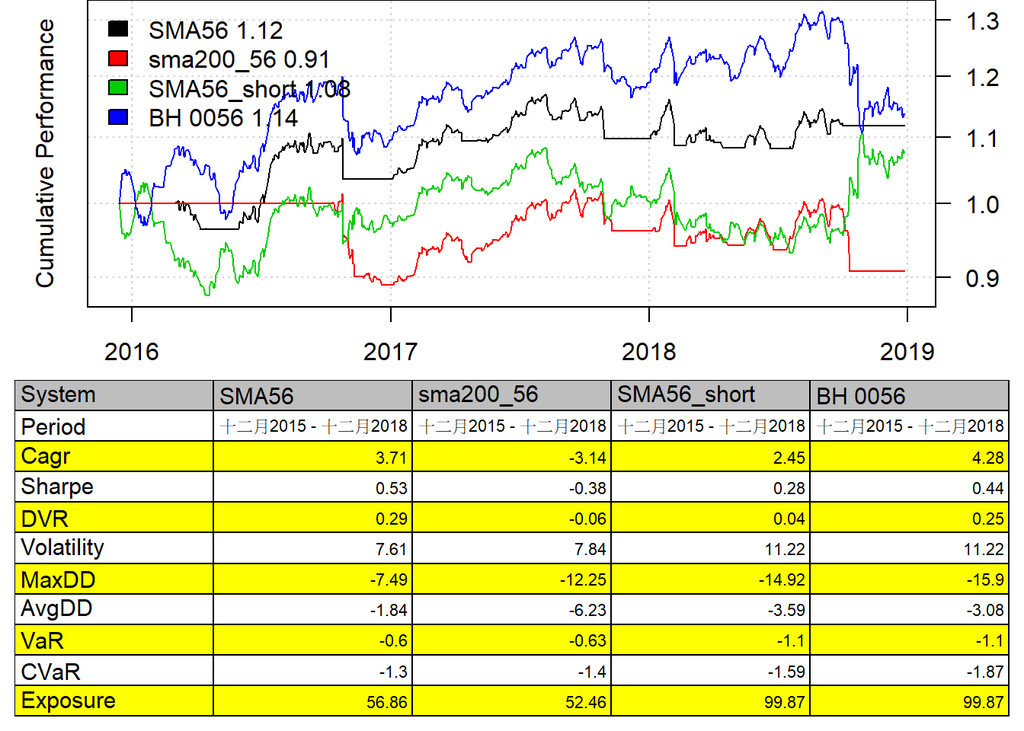

```r
models_1<-list("SMA56"= sma56.0056,
             "sma200_56"= sma200_56.0056,
             "SMA56_short" = sma56.0056.short,
             "BH 0056" = buy.hold.0056)
strategy.performance.snapshoot(models_1, T)
```

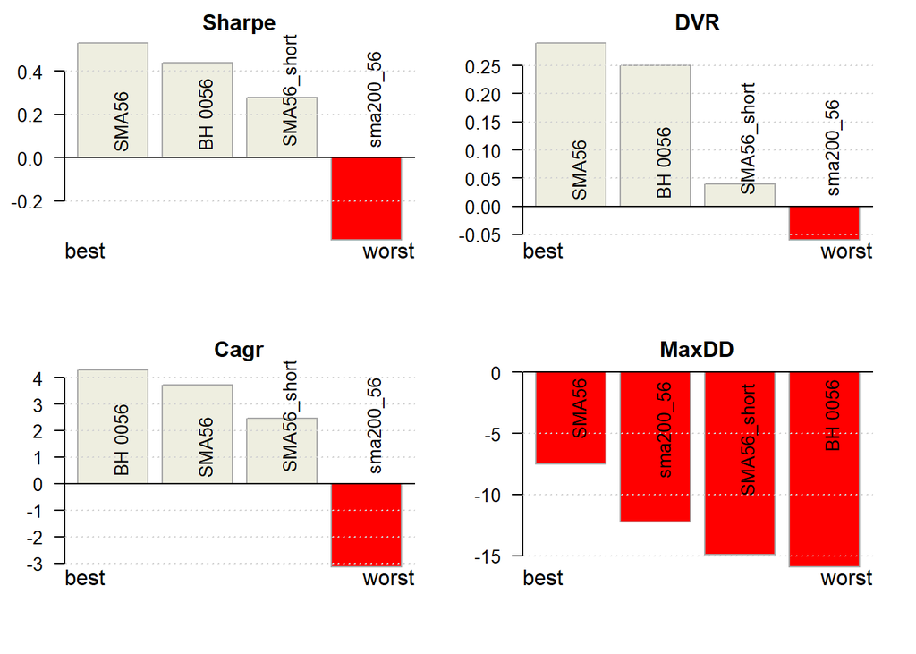

```r
strategy.performance.snapshoot(models_1, control=list(comparison=T), sort.performance=T)
```

```
##            SMA56                     sma200_56
## Period     "十二月2015 - 十二月2018" "十二月2015 - 十二月2018"
## Cagr       "3.71"                    "-3.14"
## Sharpe     "0.53"                    "-0.38"
## DVR        "0.29"                    "-0.06"
## Volatility "7.61"                    "7.84"
## MaxDD      "-7.49"                   "-12.25"
## AvgDD      "-1.84"                   "-6.23"
## VaR        "-0.6"                    "-0.63"
## CVaR       "-1.3"                    "-1.4"
## Exposure   "56.86"                   "52.46"
##            SMA56_short               BH 0056
## Period     "十二月2015 - 十二月2018" "十二月2015 - 十二月2018"
## Cagr       "2.45"                    "4.28"
## Sharpe     "0.28"                    "0.44"
## DVR        "0.04"                    "0.25"
## Volatility "11.22"                   "11.22"
## MaxDD      "-14.92"                  "-15.9"
## AvgDD      "-3.59"                   "-3.08"
## VaR        "-1.1"                    "-1.1"
## CVaR       "-1.59"                   "-1.87"
## Exposure   "99.87"                   "99.87"
```

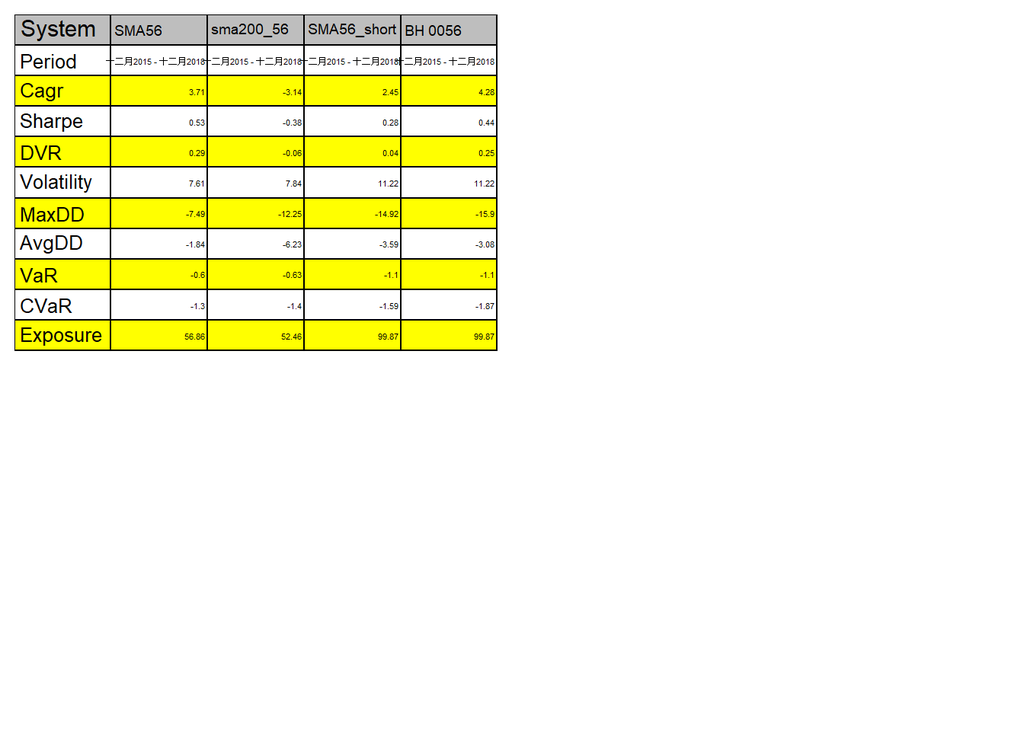

```r
plotbt.strategy.sidebyside(models_1, return.table=T)
```

```r
library(ggplot2)
all.0056<-merge.xts(sma56.0056$equity,
                    sma56.0056.short$equity,
                    sma200_56.0056$equity,
                    buy.hold.0056$equity)
colnames(all.0056)<-c("sma56", "sma56 short", "sma200_56", "BH")
head(all.0056)
```

```
##            sma56 sma56 short sma200_56       BH
## 2015-12-14     1   1.0000000         1 1.000000
## 2015-12-15     1   0.9909782         1 1.009022
## 2015-12-16     1   0.9793196         1 1.020893
## 2015-12-17     1   0.9674767         1 1.033238
## 2015-12-18     1   0.9581398         1 1.043210
## 2015-12-21     1   0.9572676         1 1.044160
```

```r
all.0056.long<-fortify(all.0056, melt=T)
head(all.0056.long)
```

```
##        Index Series Value
## 1 2015-12-14  sma56     1
## 2 2015-12-15  sma56     1
## 3 2015-12-16  sma56     1
## 4 2015-12-17  sma56     1
## 5 2015-12-18  sma56     1
## 6 2015-12-21  sma56     1
```

圖的標題為Cumulative returns of 0056s。

X軸為year，Y軸為cumulative returns。

橘色線為sma56，綠色線為sma56 short，藍色線為sma200_56，紫色線為BH。

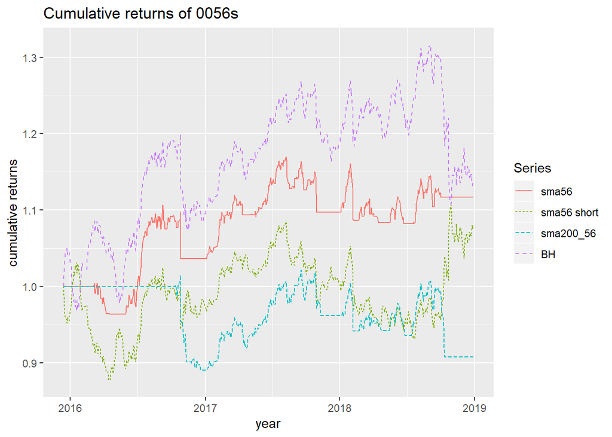

```r
title = "Cumulative returns of 0056s"
p1 = ggplot(all.0056.long, aes(x = Index, y = Value)) +
  geom_line(aes(linetype = Series, color = Series)) +
  #geom_point(aes(shape = Series))+
  xlab("year") + ylab("cumulative returns")+
  ggtitle(title)
p1
```

# 006205

讀取006205的資料。

```r
library(xts)
data1<-new.env()
data1$prices<-etf4.all.1$'006205'
prices<-data1$prices

sma6205<-SMA(prices, 50)
head(sma6205, 51)
```

```
##                SMA
## 2015-12-14      NA
## 2015-12-15      NA
## 2015-12-16      NA
## 2015-12-17      NA
## 2015-12-18      NA
## 2015-12-21      NA
## 2015-12-22      NA
## 2015-12-23      NA
## 2015-12-24      NA
## 2015-12-25      NA
## 2015-12-28      NA
## 2015-12-29      NA
## 2015-12-30      NA
## 2015-12-31      NA
## 2016-01-04      NA
## 2016-01-05      NA
## 2016-01-06      NA
## 2016-01-07      NA
## 2016-01-08      NA
## 2016-01-11      NA
## 2016-01-12      NA
## 2016-01-13      NA
## 2016-01-14      NA
## 2016-01-15      NA
## 2016-01-18      NA
## 2016-01-19      NA
## 2016-01-20      NA
## 2016-01-21      NA
## 2016-01-22      NA
## 2016-01-25      NA
## 2016-01-26      NA
## 2016-01-27      NA
## 2016-01-28      NA
## 2016-01-29      NA
## 2016-01-30      NA
## 2016-02-01      NA
## 2016-02-02      NA
## 2016-02-03      NA
## 2016-02-15      NA
## 2016-02-16      NA
## 2016-02-17      NA
## 2016-02-18      NA
## 2016-02-19      NA
## 2016-02-22      NA
## 2016-02-23      NA
## 2016-02-24      NA
## 2016-02-25      NA
## 2016-02-26      NA
## 2016-03-01      NA
## 2016-03-02 28.5936
## 2016-03-03 28.5080
```

分別看日期、價錢。

```r
bt.prep(data1, align='keep.all')
names(data1)
```

```
## [1] "prices"          "dates"           "weight"          "symbolnames"
## [5] "execution.price"
```

```r
data1$dates
```

```
##   [1] "2015-12-14" "2015-12-15" "2015-12-16" "2015-12-17" "2015-12-18"
##   [6] "2015-12-21" "2015-12-22" "2015-12-23" "2015-12-24" "2015-12-25"
##  [11] "2015-12-28" "2015-12-29" "2015-12-30" "2015-12-31" "2016-01-04"
##  [16] "2016-01-05" "2016-01-06" "2016-01-07" "2016-01-08" "2016-01-11"
##  [21] "2016-01-12" "2016-01-13" "2016-01-14" "2016-01-15" "2016-01-18"
##  [26] "2016-01-19" "2016-01-20" "2016-01-21" "2016-01-22" "2016-01-25"
##  [31] "2016-01-26" "2016-01-27" "2016-01-28" "2016-01-29" "2016-01-30"
##  [36] "2016-02-01" "2016-02-02" "2016-02-03" "2016-02-15" "2016-02-16"
##  [41] "2016-02-17" "2016-02-18" "2016-02-19" "2016-02-22" "2016-02-23"
##  [46] "2016-02-24" "2016-02-25" "2016-02-26" "2016-03-01" "2016-03-02"
##  [51] "2016-03-03" "2016-03-04" "2016-03-07" "2016-03-08" "2016-03-09"
##  [56] "2016-03-10" "2016-03-11" "2016-03-14" "2016-03-15" "2016-03-16"
##  [61] "2016-03-17" "2016-03-18" "2016-03-21" "2016-03-22" "2016-03-23"
##  [66] "2016-03-24" "2016-03-25" "2016-03-28" "2016-03-29" "2016-03-30"
##  [71] "2016-03-31" "2016-04-01" "2016-04-06" "2016-04-07" "2016-04-08"
```

[output cut: 136 more lines]

```r
data1$prices
```

```
##            prices
## 2015-12-14     NA
## 2015-12-15     NA
## 2015-12-16     NA
## 2015-12-17     NA
## 2015-12-18     NA
## 2015-12-21     NA
## 2015-12-22     NA
## 2015-12-23     NA
## 2015-12-24     NA
## 2015-12-25     NA
## 2015-12-28     NA
## 2015-12-29     NA
## 2015-12-30     NA
## 2015-12-31     NA
## 2016-01-04     NA
## 2016-01-05     NA
## 2016-01-06     NA
## 2016-01-07     NA
## 2016-01-08     NA
## 2016-01-11     NA
## 2016-01-12     NA
## 2016-01-13     NA
## 2016-01-14     NA
## 2016-01-15     NA
## 2016-01-18     NA
## 2016-01-19     NA
## 2016-01-20     NA
## 2016-01-21     NA
## 2016-01-22     NA
## 2016-01-25     NA
## 2016-01-26     NA
## 2016-01-27     NA
## 2016-01-28     NA
## 2016-01-29     NA
## 2016-01-30     NA
## 2016-02-01     NA
## 2016-02-02     NA
## 2016-02-03     NA
## 2016-02-15     NA
```

[output cut: 697 more lines]

```
## 2018-12-11     NA
## 2018-12-12     NA
## 2018-12-13     NA
## 2018-12-14     NA
## 2018-12-17     NA
## 2018-12-18     NA
## 2018-12-19     NA
## 2018-12-20     NA
## 2018-12-21     NA
## 2018-12-22     NA
## 2018-12-24     NA
## 2018-12-25     NA
## 2018-12-26     NA
## 2018-12-27     NA
## 2018-12-28     NA
```

```r
data1$prices<-prices

class(data1$dates)
```

```
## [1] "Date"
```

```r
data1$execution.price = prices
data1$weight[] = 1
buy.hold.006205 <- bt.run.share(data1, clean.signal=F, trade.summary = TRUE)
```

```
## Latest weights :
##            prices
## 2018-12-28    100
##
## Performance summary :
##  CAGR    Best    Worst
##  -6.5    5   -5.6
```

```r
buy.hold.006205 <-bt.run(data1)
```

```
## Latest weights :
##            prices
## 2018-12-28    100
##
## Performance summary :
##  CAGR    Best    Worst
##  -6.5    5   -5.6
```

讀取sma 200天的資料。

```r
prices<-data1$prices
sma200_6205<-SMA(prices, 200)
head(sma200_6205, 201)
```

```
##                SMA
## 2015-12-14      NA
## 2015-12-15      NA
## 2015-12-16      NA
## 2015-12-17      NA
## 2015-12-18      NA
## 2015-12-21      NA
## 2015-12-22      NA
## 2015-12-23      NA
## 2015-12-24      NA
## 2015-12-25      NA
## 2015-12-28      NA
## 2015-12-29      NA
## 2015-12-30      NA
## 2015-12-31      NA
## 2016-01-04      NA
## 2016-01-05      NA
## 2016-01-06      NA
## 2016-01-07      NA
## 2016-01-08      NA
## 2016-01-11      NA
## 2016-01-12      NA
## 2016-01-13      NA
## 2016-01-14      NA
## 2016-01-15      NA
## 2016-01-18      NA
## 2016-01-19      NA
## 2016-01-20      NA
## 2016-01-21      NA
## 2016-01-22      NA
## 2016-01-25      NA
## 2016-01-26      NA
## 2016-01-27      NA
## 2016-01-28      NA
## 2016-01-29      NA
## 2016-01-30      NA
## 2016-02-01      NA
## 2016-02-02      NA
## 2016-02-03      NA
## 2016-02-15      NA
```

[output cut: 147 more lines]

```
## 2016-09-19      NA
## 2016-09-20      NA
## 2016-09-21      NA
## 2016-09-22      NA
## 2016-09-23      NA
## 2016-09-26      NA
## 2016-09-29      NA
## 2016-09-30      NA
## 2016-10-03      NA
## 2016-10-04      NA
## 2016-10-05      NA
## 2016-10-06      NA
## 2016-10-07      NA
## 2016-10-11 27.4799
## 2016-10-12 27.4596
```

```r
data1$weight[] <- iif(prices >= sma200_6205, 1, 0)
sma200_6205.006205 <- bt.run(data1, trade.summary=T)
```

```
## Latest weights :
##            prices
## 2018-12-28      0
##
## Performance summary :
##  CAGR    Best    Worst
##  0.5 3.2 -5.6
```

讀取sma 50天的資料。

```r
sma6205<-SMA(prices, 50)
head(sma6205, 51)
```

```
##                SMA
## 2015-12-14      NA
## 2015-12-15      NA
## 2015-12-16      NA
## 2015-12-17      NA
## 2015-12-18      NA
## 2015-12-21      NA
## 2015-12-22      NA
## 2015-12-23      NA
## 2015-12-24      NA
## 2015-12-25      NA
## 2015-12-28      NA
## 2015-12-29      NA
## 2015-12-30      NA
## 2015-12-31      NA
## 2016-01-04      NA
## 2016-01-05      NA
## 2016-01-06      NA
## 2016-01-07      NA
## 2016-01-08      NA
## 2016-01-11      NA
## 2016-01-12      NA
## 2016-01-13      NA
## 2016-01-14      NA
## 2016-01-15      NA
## 2016-01-18      NA
## 2016-01-19      NA
## 2016-01-20      NA
## 2016-01-21      NA
## 2016-01-22      NA
## 2016-01-25      NA
## 2016-01-26      NA
## 2016-01-27      NA
## 2016-01-28      NA
## 2016-01-29      NA
## 2016-01-30      NA
## 2016-02-01      NA
## 2016-02-02      NA
## 2016-02-03      NA
## 2016-02-15      NA
## 2016-02-16      NA
## 2016-02-17      NA
## 2016-02-18      NA
## 2016-02-19      NA
## 2016-02-22      NA
## 2016-02-23      NA
## 2016-02-24      NA
## 2016-02-25      NA
## 2016-02-26      NA
## 2016-03-01      NA
## 2016-03-02 28.5936
## 2016-03-03 28.5080
```

```r
data1$weight[] <- iif(prices >= sma6205, 1, 0)
sma6205.006205 <- bt.run(data1, trade.summary=T)
```

```
## Latest weights :
##            prices
## 2018-12-28      0
##
## Performance summary :
##  CAGR    Best    Worst
##  -3.4    2.2 -5.6
```

```r
data1$weight[] <- iif(prices >= sma6205, 1, -1)
sma6205.006205.short <- bt.run(data1, trade.summary=T)
```

```
## Latest weights :
##            prices
## 2018-12-28   -100
##
## Performance summary :
##  CAGR    Best    Worst
##  -2.1    5.1 -5.6
```

# 第一、二張圖：

黑色線為SMA6205 0.90，紅色線為SMA200_6205 1.02，綠色線為SMA6205_short 0.94，藍色線為BH 006205 0.81。並顯示出表格。

# 第三張圖：

顯示出Sharpe、DVR、Cagr、MaxDD四個的長條圖。

# 第四張圖：

顯示為表格。

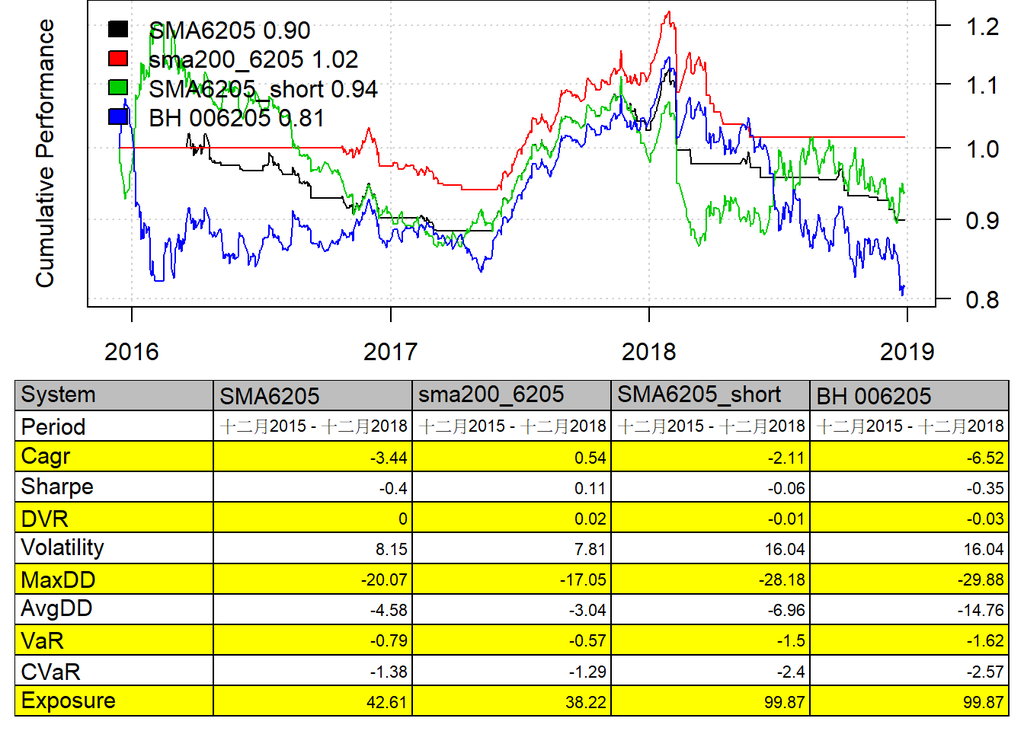

```r
models_2<-list("SMA6205"= sma6205.006205,
               "sma200_6205"= sma200_6205.006205,
               "SMA6205_short" = sma6205.006205.short,
               "BH 006205" = buy.hold.006205)
strategy.performance.snapshoot(models_2, T)
```

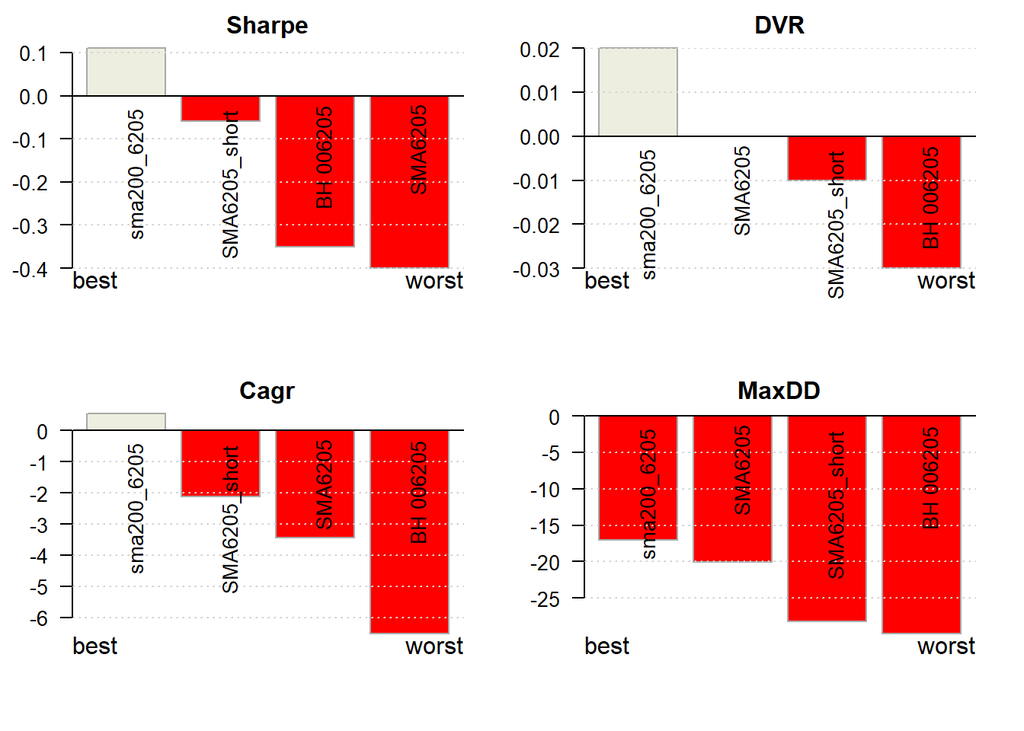

```r
strategy.performance.snapshoot(models_2, control=list(comparison=T), sort.performance=T)
```

```
##            SMA6205                   sma200_6205
## Period     "十二月2015 - 十二月2018" "十二月2015 - 十二月2018"
## Cagr       "-3.44"                   "0.54"
## Sharpe     "-0.4"                    "0.11"
## DVR        "0"                       "0.02"
## Volatility "8.15"                    "7.81"
## MaxDD      "-20.07"                  "-17.05"
## AvgDD      "-4.58"                   "-3.04"
## VaR        "-0.79"                   "-0.57"
## CVaR       "-1.38"                   "-1.29"
## Exposure   "42.61"                   "38.22"
##            SMA6205_short             BH 006205
## Period     "十二月2015 - 十二月2018" "十二月2015 - 十二月2018"
## Cagr       "-2.11"                   "-6.52"
## Sharpe     "-0.06"                   "-0.35"
## DVR        "-0.01"                   "-0.03"
## Volatility "16.04"                   "16.04"
## MaxDD      "-28.18"                  "-29.88"
## AvgDD      "-6.96"                   "-14.76"
## VaR        "-1.5"                    "-1.62"
## CVaR       "-2.4"                    "-2.57"
## Exposure   "99.87"                   "99.87"
```

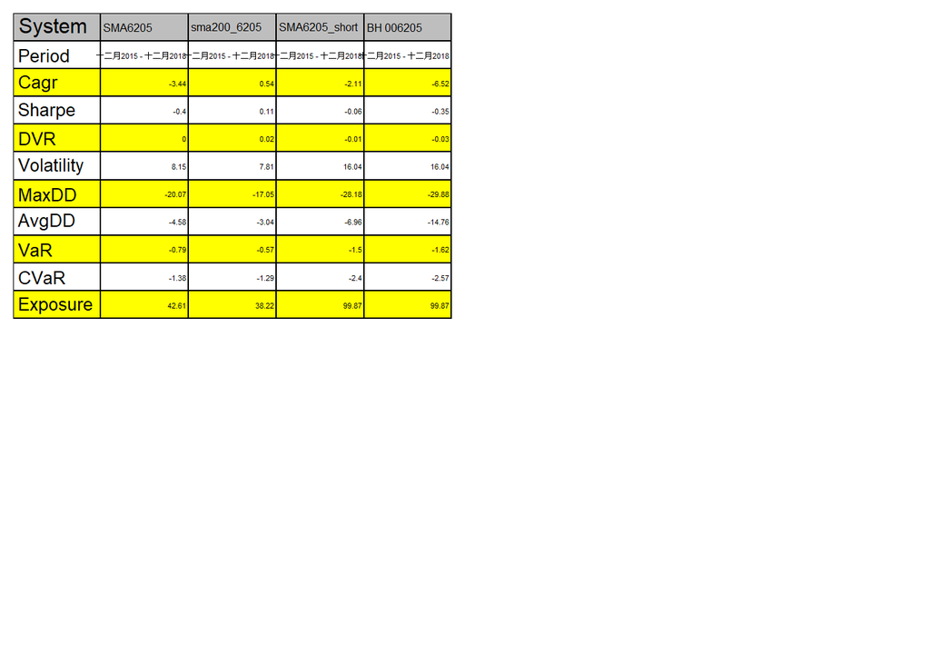

```r
plotbt.strategy.sidebyside(models_2, return.table=T)
```

```r
library(ggplot2)
all.006205<-merge.xts(sma6205.006205$equity,
                      sma6205.006205.short$equity,
                      sma200_6205.006205$equity,
                      buy.hold.006205$equity)
colnames(all.006205)<-c("sma6205", "sma6205 short", "sma200_6205", "BH")
head(all.006205)
```

```
##            sma6205 sma6205 short sma200_6205       BH
## 2015-12-14       1     1.0000000           1 1.000000
## 2015-12-15       1     0.9780504           1 1.021950
## 2015-12-16       1     0.9777414           1 1.022272
## 2015-12-17       1     0.9657010           1 1.034861
## 2015-12-18       1     0.9605804           1 1.040349
## 2015-12-21       1     0.9489568           1 1.052937
```

```r
all.006205.long<-fortify(all.006205, melt=T)
head(all.006205.long)
```

```
##        Index  Series Value
## 1 2015-12-14 sma6205     1
## 2 2015-12-15 sma6205     1
## 3 2015-12-16 sma6205     1
## 4 2015-12-17 sma6205     1
## 5 2015-12-18 sma6205     1
## 6 2015-12-21 sma6205     1
```

圖的標題為Cumulative returns of 006205s。

X軸為year，Y軸為cumulative returns。

橘色線為sma6205，綠色線為sma6205 short，藍色線為sma200_6205，紫色線為BH。

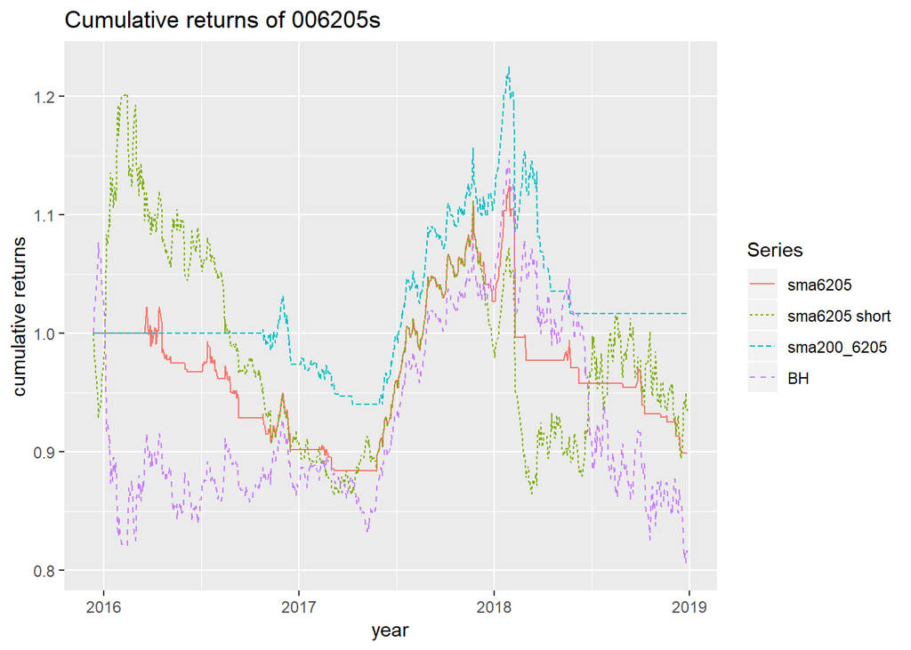

```r
title = "Cumulative returns of 006205s"
p2 = ggplot(all.006205.long, aes(x = Index, y = Value)) +
  geom_line(aes(linetype = Series, color = Series)) +
  #geom_point(aes(shape = Series))+
  xlab("year") + ylab("cumulative returns")+
  ggtitle(title)
p2
```

# 00646

讀取00646的資料。

```r
library(xts)
data1<-new.env()
data1$prices<-etf4.all.1$'00646'
prices<-data1$prices

sma646<-SMA(prices, 50)
head(sma646, 51)
```

```
##                SMA
## 2015-12-14      NA
## 2015-12-15      NA
## 2015-12-16      NA
## 2015-12-17      NA
## 2015-12-18      NA
## 2015-12-21      NA
## 2015-12-22      NA
## 2015-12-23      NA
## 2015-12-24      NA
## 2015-12-25      NA
## 2015-12-28      NA
## 2015-12-29      NA
## 2015-12-30      NA
## 2015-12-31      NA
## 2016-01-04      NA
## 2016-01-05      NA
## 2016-01-06      NA
## 2016-01-07      NA
## 2016-01-08      NA
## 2016-01-11      NA
## 2016-01-12      NA
## 2016-01-13      NA
## 2016-01-14      NA
## 2016-01-15      NA
## 2016-01-18      NA
## 2016-01-19      NA
## 2016-01-20      NA
## 2016-01-21      NA
## 2016-01-22      NA
## 2016-01-25      NA
## 2016-01-26      NA
## 2016-01-27      NA
## 2016-01-28      NA
## 2016-01-29      NA
## 2016-01-30      NA
## 2016-02-01      NA
## 2016-02-02      NA
## 2016-02-03      NA
## 2016-02-15      NA
## 2016-02-16      NA
## 2016-02-17      NA
## 2016-02-18      NA
## 2016-02-19      NA
## 2016-02-22      NA
## 2016-02-23      NA
## 2016-02-24      NA
## 2016-02-25      NA
## 2016-02-26      NA
## 2016-03-01      NA
## 2016-03-02 19.2538
## 2016-03-03 19.2522
```

分別看日期、價錢。

```r
bt.prep(data1, align='keep.all')
names(data1)
```

```
## [1] "prices"          "dates"           "weight"          "symbolnames"
## [5] "execution.price"
```

```r
data1$dates
```

```
##   [1] "2015-12-14" "2015-12-15" "2015-12-16" "2015-12-17" "2015-12-18"
##   [6] "2015-12-21" "2015-12-22" "2015-12-23" "2015-12-24" "2015-12-25"
##  [11] "2015-12-28" "2015-12-29" "2015-12-30" "2015-12-31" "2016-01-04"
##  [16] "2016-01-05" "2016-01-06" "2016-01-07" "2016-01-08" "2016-01-11"
##  [21] "2016-01-12" "2016-01-13" "2016-01-14" "2016-01-15" "2016-01-18"
##  [26] "2016-01-19" "2016-01-20" "2016-01-21" "2016-01-22" "2016-01-25"
##  [31] "2016-01-26" "2016-01-27" "2016-01-28" "2016-01-29" "2016-01-30"
##  [36] "2016-02-01" "2016-02-02" "2016-02-03" "2016-02-15" "2016-02-16"
##  [41] "2016-02-17" "2016-02-18" "2016-02-19" "2016-02-22" "2016-02-23"
##  [46] "2016-02-24" "2016-02-25" "2016-02-26" "2016-03-01" "2016-03-02"
##  [51] "2016-03-03" "2016-03-04" "2016-03-07" "2016-03-08" "2016-03-09"
##  [56] "2016-03-10" "2016-03-11" "2016-03-14" "2016-03-15" "2016-03-16"
##  [61] "2016-03-17" "2016-03-18" "2016-03-21" "2016-03-22" "2016-03-23"
##  [66] "2016-03-24" "2016-03-25" "2016-03-28" "2016-03-29" "2016-03-30"
##  [71] "2016-03-31" "2016-04-01" "2016-04-06" "2016-04-07" "2016-04-08"
```

[output cut: 136 more lines]

```r
data1$prices
```

```
##            prices
## 2015-12-14     NA
## 2015-12-15     NA
## 2015-12-16     NA
## 2015-12-17     NA
## 2015-12-18     NA
## 2015-12-21     NA
## 2015-12-22     NA
## 2015-12-23     NA
## 2015-12-24     NA
## 2015-12-25     NA
## 2015-12-28     NA
## 2015-12-29     NA
## 2015-12-30     NA
## 2015-12-31     NA
## 2016-01-04     NA
## 2016-01-05     NA
## 2016-01-06     NA
## 2016-01-07     NA
## 2016-01-08     NA
## 2016-01-11     NA
## 2016-01-12     NA
## 2016-01-13     NA
## 2016-01-14     NA
## 2016-01-15     NA
## 2016-01-18     NA
## 2016-01-19     NA
## 2016-01-20     NA
## 2016-01-21     NA
## 2016-01-22     NA
## 2016-01-25     NA
## 2016-01-26     NA
## 2016-01-27     NA
## 2016-01-28     NA
## 2016-01-29     NA
## 2016-01-30     NA
## 2016-02-01     NA
## 2016-02-02     NA
## 2016-02-03     NA
## 2016-02-15     NA
```

[output cut: 697 more lines]

```
## 2018-12-11     NA
## 2018-12-12     NA
## 2018-12-13     NA
## 2018-12-14     NA
## 2018-12-17     NA
## 2018-12-18     NA
## 2018-12-19     NA
## 2018-12-20     NA
## 2018-12-21     NA
## 2018-12-22     NA
## 2018-12-24     NA
## 2018-12-25     NA
## 2018-12-26     NA
## 2018-12-27     NA
## 2018-12-28     NA
```

```r
data1$prices<-prices

class(data1$dates)
```

```
## [1] "Date"
```

```r
data1$execution.price = prices
data1$weight[] = 1
buy.hold.00646 <- bt.run.share(data1, clean.signal=F, trade.summary = TRUE)
```

```
## Latest weights :
##            prices
## 2018-12-28    100
##
## Performance summary :
##  CAGR    Best    Worst
##  5.7 3.7 -3.8
```

```r
buy.hold.00646 <-bt.run(data1)
```

```
## Latest weights :
##            prices
## 2018-12-28    100
##
## Performance summary :
##  CAGR    Best    Worst
##  5.7 3.7 -3.8
```

讀取sma 200天的資料。

```r
prices<-data1$prices
sma200_646<-SMA(prices, 200)
head(sma200_646, 201)
```

```
##                SMA
## 2015-12-14      NA
## 2015-12-15      NA
## 2015-12-16      NA
## 2015-12-17      NA
## 2015-12-18      NA
## 2015-12-21      NA
## 2015-12-22      NA
## 2015-12-23      NA
## 2015-12-24      NA
## 2015-12-25      NA
## 2015-12-28      NA
## 2015-12-29      NA
## 2015-12-30      NA
## 2015-12-31      NA
## 2016-01-04      NA
## 2016-01-05      NA
## 2016-01-06      NA
## 2016-01-07      NA
## 2016-01-08      NA
## 2016-01-11      NA
## 2016-01-12      NA
## 2016-01-13      NA
## 2016-01-14      NA
## 2016-01-15      NA
## 2016-01-18      NA
## 2016-01-19      NA
## 2016-01-20      NA
## 2016-01-21      NA
## 2016-01-22      NA
## 2016-01-25      NA
## 2016-01-26      NA
## 2016-01-27      NA
## 2016-01-28      NA
## 2016-01-29      NA
## 2016-01-30      NA
## 2016-02-01      NA
## 2016-02-02      NA
## 2016-02-03      NA
## 2016-02-15      NA
```

[output cut: 147 more lines]

```
## 2016-09-19      NA
## 2016-09-20      NA
## 2016-09-21      NA
## 2016-09-22      NA
## 2016-09-23      NA
## 2016-09-26      NA
## 2016-09-29      NA
## 2016-09-30      NA
## 2016-10-03      NA
## 2016-10-04      NA
## 2016-10-05      NA
## 2016-10-06      NA
## 2016-10-07      NA
## 2016-10-11 19.8460
## 2016-10-12 19.8486
```

```r
data1$weight[] <- iif(prices >= sma200_646, 1, 0)
sma200_646.00646 <- bt.run(data1, trade.summary=T)
```

```
## Latest weights :
##            prices
## 2018-12-28      0
##
## Performance summary :
##  CAGR    Best    Worst
##  3.5 2.7 -3.8
```

讀取sma 50天的資料。

```r
sma646<-SMA(prices, 50)
head(sma646, 51)
```

```
##                SMA
## 2015-12-14      NA
## 2015-12-15      NA
## 2015-12-16      NA
## 2015-12-17      NA
## 2015-12-18      NA
## 2015-12-21      NA
## 2015-12-22      NA
## 2015-12-23      NA
## 2015-12-24      NA
## 2015-12-25      NA
## 2015-12-28      NA
## 2015-12-29      NA
## 2015-12-30      NA
## 2015-12-31      NA
## 2016-01-04      NA
## 2016-01-05      NA
## 2016-01-06      NA
## 2016-01-07      NA
## 2016-01-08      NA
## 2016-01-11      NA
## 2016-01-12      NA
## 2016-01-13      NA
## 2016-01-14      NA
## 2016-01-15      NA
## 2016-01-18      NA
## 2016-01-19      NA
## 2016-01-20      NA
## 2016-01-21      NA
## 2016-01-22      NA
## 2016-01-25      NA
## 2016-01-26      NA
## 2016-01-27      NA
## 2016-01-28      NA
## 2016-01-29      NA
## 2016-01-30      NA
## 2016-02-01      NA
## 2016-02-02      NA
## 2016-02-03      NA
## 2016-02-15      NA
## 2016-02-16      NA
## 2016-02-17      NA
## 2016-02-18      NA
## 2016-02-19      NA
## 2016-02-22      NA
## 2016-02-23      NA
## 2016-02-24      NA
## 2016-02-25      NA
## 2016-02-26      NA
## 2016-03-01      NA
## 2016-03-02 19.2538
## 2016-03-03 19.2522
```

```r
data1$weight[] <- iif(prices >= sma646, 1, 0)
sma646.00646 <- bt.run(data1, trade.summary=T)
```

```
## Latest weights :
##            prices
## 2018-12-28      0
##
## Performance summary :
##  CAGR    Best    Worst
##  3.6 1.7 -3.8
```

```r
data1$weight[] <- iif(prices >= sma646, 1, -1)
sma646.00646.short <- bt.run(data1, trade.summary=T)
```

```
## Latest weights :
##            prices
## 2018-12-28   -100
##
## Performance summary :
##  CAGR    Best    Worst
##  0.8 3   -3.8
```

# 第一、二張圖：

黑色線為SMA646 1.11，紅色線為SMA200_646 1.11，綠色線為SMA646_short 1.02，藍色線為BH 00646 1.19。並顯示出表格。

# 第三張圖：

顯示出Sharpe、DVR、Cagr、MaxDD四個的長條圖。

# 第四張圖：

顯示為表格。

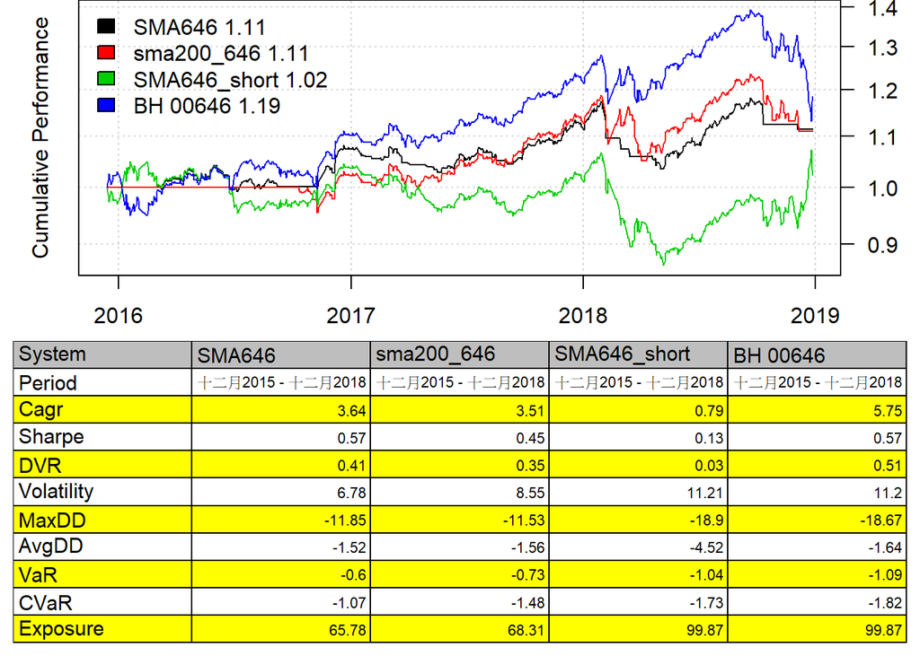

```r
models_3<-list("SMA646"= sma646.00646,
               "sma200_646"= sma200_646.00646,
               "SMA646_short" = sma646.00646.short,
               "BH 00646" = buy.hold.00646)
strategy.performance.snapshoot(models_3, T)
```

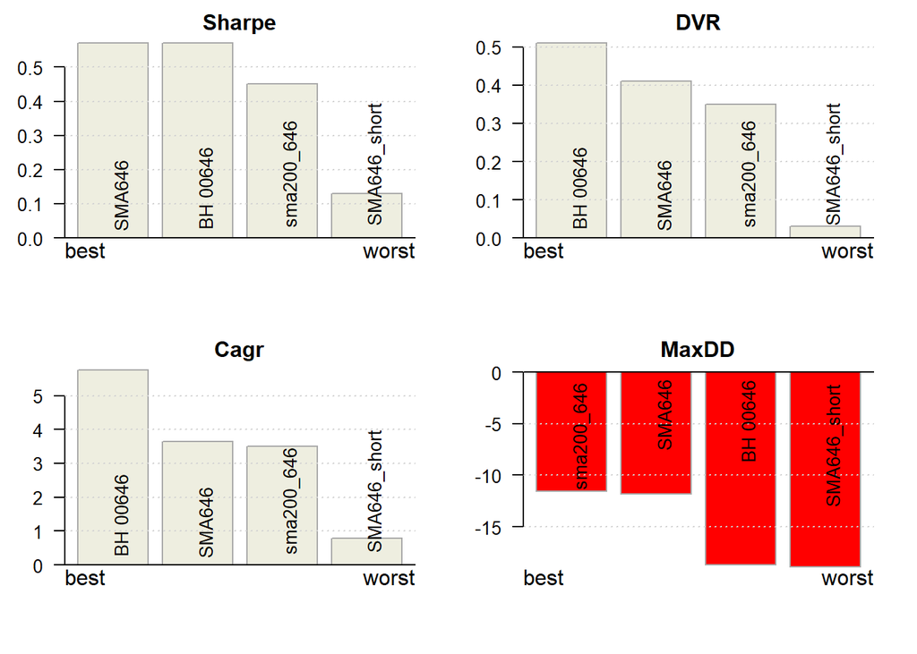

```r
strategy.performance.snapshoot(models_3, control=list(comparison=T), sort.performance=T)
```

```
##            SMA646                    sma200_646
## Period     "十二月2015 - 十二月2018" "十二月2015 - 十二月2018"
## Cagr       "3.64"                    "3.51"
## Sharpe     "0.57"                    "0.45"
## DVR        "0.41"                    "0.35"
## Volatility "6.78"                    "8.55"
## MaxDD      "-11.85"                  "-11.53"
## AvgDD      "-1.52"                   "-1.56"
## VaR        "-0.6"                    "-0.73"
## CVaR       "-1.07"                   "-1.48"
## Exposure   "65.78"                   "68.31"
##            SMA646_short              BH 00646
## Period     "十二月2015 - 十二月2018" "十二月2015 - 十二月2018"
## Cagr       "0.79"                    "5.75"
## Sharpe     "0.13"                    "0.57"
## DVR        "0.03"                    "0.51"
## Volatility "11.21"                   "11.2"
## MaxDD      "-18.9"                   "-18.67"
## AvgDD      "-4.52"                   "-1.64"
## VaR        "-1.04"                   "-1.09"
## CVaR       "-1.73"                   "-1.82"
## Exposure   "99.87"                   "99.87"
```

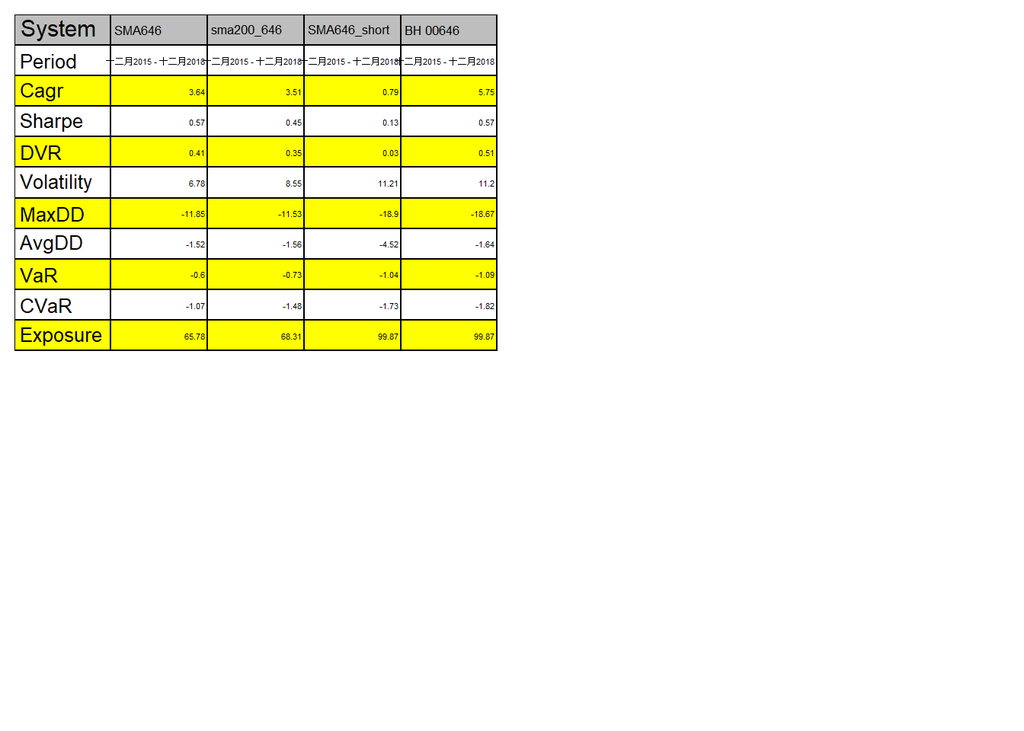

```r
plotbt.strategy.sidebyside(models_3, return.table=T)
```

```r
library(ggplot2)
all.00646<-merge.xts(sma646.00646$equity,
                      sma646.00646.short$equity,
                      sma200_646.00646$equity,
                      buy.hold.00646$equity)
colnames(all.00646)<-c("sma646", "sma646 short", "sma200_646", "BH")
head(all.00646)
```

```
##            sma646 sma646 short sma200_646       BH
## 2015-12-14      1    1.0000000          1 1.000000
## 2015-12-15      1    0.9918117          1 1.008188
## 2015-12-16      1    0.9867771          1 1.013306
## 2015-12-17      1    0.9743178          1 1.026100
## 2015-12-18      1    0.9830648          1 1.016888
## 2015-12-21      1    0.9944440          1 1.005118
```

```r
all.00646.long<-fortify(all.00646, melt=T)
head(all.00646.long)
```

```
##        Index Series Value
## 1 2015-12-14 sma646     1
## 2 2015-12-15 sma646     1
## 3 2015-12-16 sma646     1
## 4 2015-12-17 sma646     1
## 5 2015-12-18 sma646     1
## 6 2015-12-21 sma646     1
```

圖的標題為Cumulative returns of 00646s。

X軸為year，Y軸為cumulative returns。

橘色線為sma646，綠色線為sma646 short，藍色線為sma200_646，紫色線為BH。

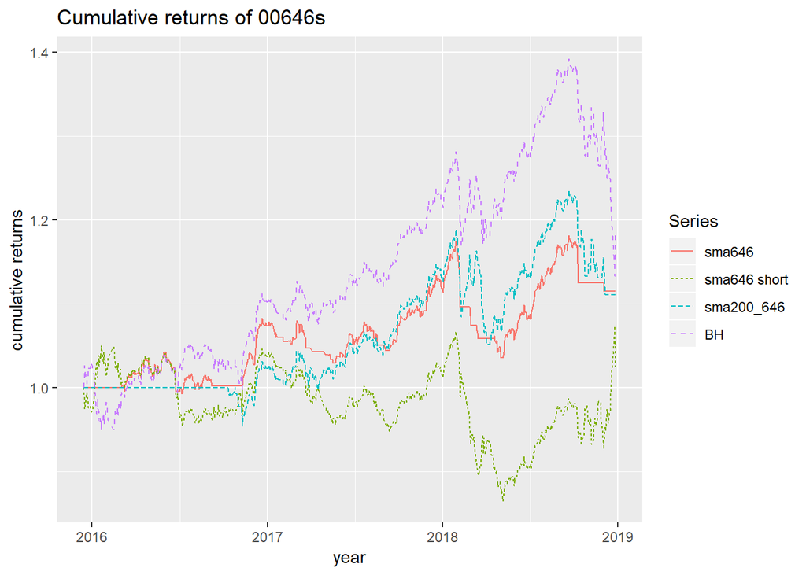

```r
title = "Cumulative returns of 00646s"
p3 = ggplot(all.00646.long, aes(x = Index, y = Value)) +
  geom_line(aes(linetype = Series, color = Series)) +
  #geom_point(aes(shape = Series))+
  xlab("year") + ylab("cumulative returns")+
  ggtitle(title)
p3
```